# projetMAD

Project of MAD

owner: Guangyue CHEN

# E1 Simulation

### Q1 Simulate sample of 1000 vectors from a 2 dimensional mixture with 2 components

```r
library(MASS)
nks<-rmultinom(1,1000,prob=c(1/2,1/2))
mu <- as.vector(c(1,2))
Sigma1 <- matrix(c(1,0,0,1),2,2)
Sigma2 <- 4*Sigma1

samples<- rbind( mvrnorm(nks[1], mu, Sigma1), mvrnorm(nks[2], mu, Sigma2))
```

### Q2 Display the sample

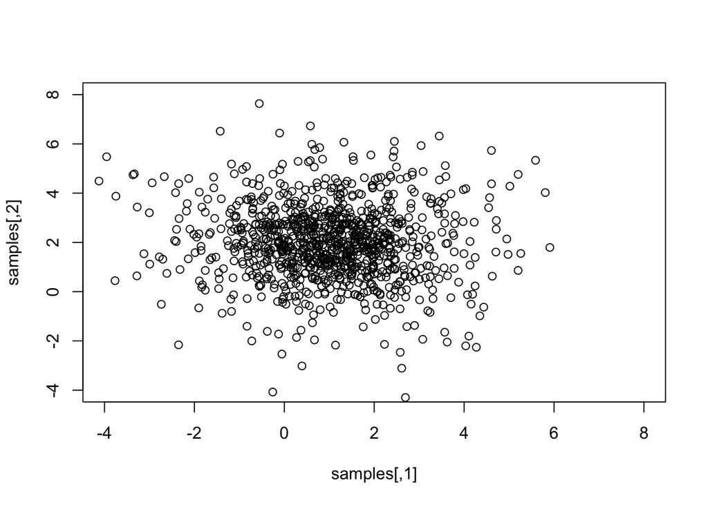

```r
plot(samples,xlim=c(-4,8),ylim=c(-4,8))
```

###Q3 Display the coutour plot of the two dimensional density. There are two ways to show it.

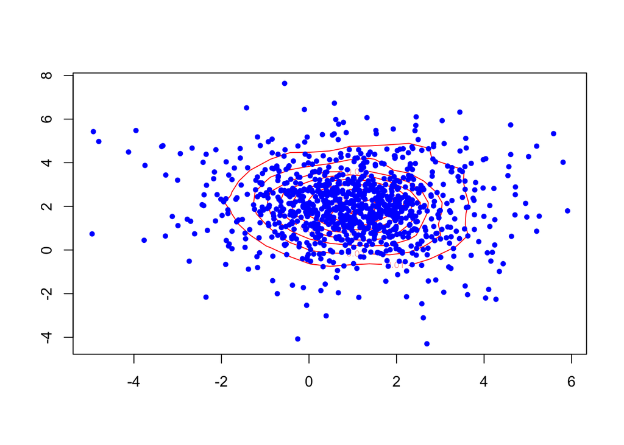

```r
require("ggplot2")
z<-kde2d(samples[,1],samples[,2])
contour(z,col="red")
#plot
points(samples[,c(1,2)],col="blue",pch=20)
```

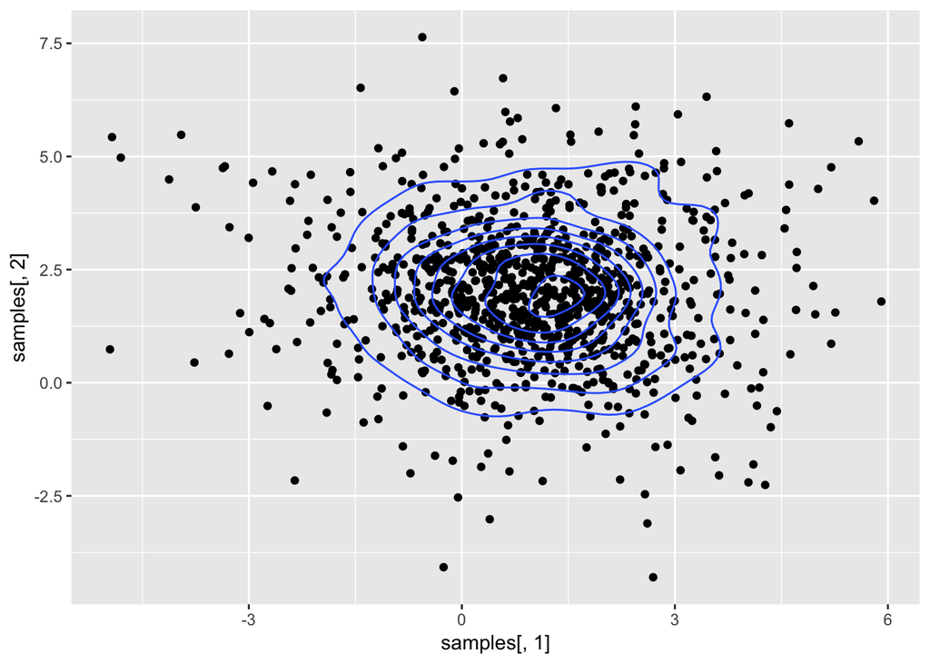

```r
ggplot(data.frame(samples), aes(samples[,1], samples[,2])) + geom_point() + stat_density2d()
```

#E2 Exercise 2 Mclust versus kmeans

### Q1 Run Mclust on the simulated data from the first exercise and comment the result.

```r
require("mclust")
Mclust(samples, 2, modelNames = "VII") -> res
summary(res)
```

```
## ----------------------------------------------------
## Gaussian finite mixture model fitted by EM algorithm
## ----------------------------------------------------
##
## Mclust VII (spherical, varying volume) model with 2 components:
##
##  log.likelihood    n df       BIC       ICL
##        -3683.43 1000  7 -7415.214 -8104.997
##
## Clustering table:
##   1   2
## 495 505
```

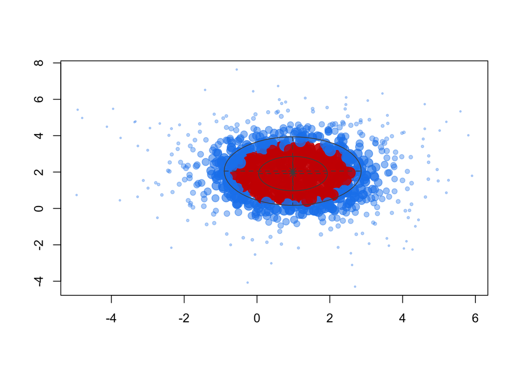

```r
plot(res,"uncertainty")
```

$comment$ We find that the clustering is not exactly same as the real classification, and there are so many points are uncertain.

### Q2 Estimate the parameters of the simulated data from the first exercise using mclust.

```r
print("pi")
```

```
## [1] "pi"
```

```r
res$parameters$pro
```

```
## [1] 0.5785879 0.4214121
```

```r
print("mu")
```

```
## [1] "mu"
```

```r
res$parameters$mean
```

```
##           [,1]      [,2]
## [1,] 0.9807725 0.9889714
## [2,] 2.0544600 1.9159560
```

```r
print("Sigma")
```

```
## [1] "Sigma"
```

```r
res$parameters$variance$sigma
```

```
## , , 1
##
##          [,1]     [,2]
## [1,] 3.542352 0.000000
## [2,] 0.000000 3.542352
##
## , , 2
##
##           [,1]      [,2]
## [1,] 0.8928414 0.0000000
## [2,] 0.0000000 0.8928414
```

### Q3 Find a partition of the simulated data into two classes using mclust

```r
res$classification
```

```
##    [1] 1 2 2 2 2 1 2 2 1 2 2 2 1 2 1 1 2 2 2 2 2 2 2 2 1 2 2 2 2 2 1 2 2 1
##   [35] 2 2 2 1 2 1 1 1 2 2 2 1 1 2 2 2 2 1 1 2 2 1 1 2 2 1 2 2 2 1 2 2 1 2
##   [69] 2 2 1 1 1 2 2 2 2 2 2 2 2 2 1 2 2 2 2 1 2 1 1 1 2 2 2 1 2 2 2 2 2 2
##  [103] 1 2 2 2 2 2 2 1 1 1 1 2 2 2 1 2 2 2 2 2 1 2 2 2 2 1 2 2 1 2 2 2 2 1
##  [137] 2 2 2 1 1 2 2 2 2 2 2 2 2 1 1 2 1 2 1 2 1 2 2 2 2 1 1 2 2 1 2 2 2 1
##  [171] 2 2 2 1 2 2 2 1 1 1 2 1 2 2 2 2 1 2 2 2 1 2 2 1 2 2 2 2 2 1 2 2 2 2
##  [205] 1 2 2 2 2 2 2 1 2 2 2 1 2 1 2 2 2 2 1 1 2 1 2 1 2 2 2 2 1 1 2 1 2 2
##  [239] 2 1 2 2 2 1 2 1 2 2 2 1 2 2 2 2 2 2 2 2 2 2 2 2 1 2 2 2 2 1 2 2 2 2
##  [273] 2 2 2 1 2 2 1 1 2 2 2 1 2 2 1 2 1 2 1 2 2 2 2 2 2 1 2 2 1 2 2 2 2 2
##  [307] 2 1 2 2 2 1 2 2 2 2 1 1 2 2 1 2 2 2 2 2 2 1 1 2 2 2 2 1 1 2 2 2 2 2
##  [341] 2 2 2 1 2 1 2 2 2 1 2 2 2 2 1 2 2 2 1 2 2 2 2 1 1 1 1 1 2 2 2 2 2 1
##  [375] 2 1 2 2 2 2 2 2 1 1 2 2 1 2 2 2 2 2 2 2 2 2 2 2 2 2 2 2 2 2 2 2 2 2
##  [409] 2 2 1 2 2 2 1 2 1 2 2 2 1 2 2 2 2 2 2 1 1 1 2 1 1 2 1 2 2 2 2 1 2 2
##  [443] 2 2 2 2 1 1 2 1 1 2 2 1 1 2 2 2 1 2 2 2 2 2 2 2 2 2 1 1 2 2 2 2 1 2
##  [477] 2 2 1 2 2 2 2 2 1 2 2 1 2 1 2 1 2 2 2 2 2 1 1 2 2 1 2 2 2 2 2 2 2 1
##  [511] 1 1 2 1 1 1 1 1 1 1 2 1 1 1 1 2 1 2 1 1 1 2 2 1 1 1 1 1 1 1 1 2 2 1
##  [545] 2 1 1 1 2 1 1 1 1 1 2 1 1 2 2 1 1 1 1 1 1 1 1 1 1 1 2 1 1 2 2 1 2 2
##  [579] 1 2 1 1 1 1 2 1 1 2 1 1 1 2 2 1 2 1 2 2 1 2 2 1 1 1 1 1 1 1 2 1 2 2
##  [613] 1 1 1 2 2 1 2 1 1 2 1 2 1 2 1 2 2 1 1 2 2 2 1 1 1 1 2 1 2 1 1 2 1 2
##  [647] 1 1 2 1 1 2 1 1 1 1 1 2 2 1 2 1 2 2 1 2 2 2 1 1 1 1 1 1 2 1 2 1 1 1
##  [681] 1 1 1 1 1 1 1 1 1 2 1 2 1 2 1 1 2 1 2 2 1 2 1 1 1 1 2 1 1 1 2 1 1 1
##  [715] 1 1 1 1 1 1 2 1 1 1 1 1 1 1 1 1 1 2 1 1 1 2 1 1 1 1 1 2 2 1 1 1 1 1
##  [749] 1 1 1 1 1 1 1 1 1 1 1 1 1 1 1 2 1 1 2 1 1 2 1 1 1 1 1 2 1 1 2 2 1 1
##  [783] 1 1 1 1 1 1 1 1 1 1 1 1 1 1 1 2 1 2 1 2 1 1 2 1 1 2 1 1 1 1 2 1 1 1
##  [817] 2 2 1 2 2 1 2 1 1 1 1 1 1 1 1 1 1 2 2 1 1 2 2 1 1 1 1 1 2 1 1 1 1 1
##  [851] 1 2 2 1 2 1 2 1 1 2 1 1 2 1 1 2 1 1 1 1 2 1 1 1 2 1 1 1 1 1 2 1 2 1
##  [885] 1 2 1 2 2 1 1 1 2 1 2 1 2 1 1 1 2 2 1 1 1 1 1 1 1 2 1 1 1 1 1 1 2 1
##  [919] 1 1 2 1 1 1 2 1 1 1 1 1 1 1 1 1 1 1 2 1 1 1 1 1 1 1 1 1 1 1 2 1 1 1
##  [953] 2 1 1 1 2 1 2 1 2 1 2 1 2 1 1 1 2 1 1 1 2 1 2 1 1 2 1 2 1 1 1 2 2 1
##  [987] 1 2 1 2 1 1 1 2 1 2 1 1 1 1
```

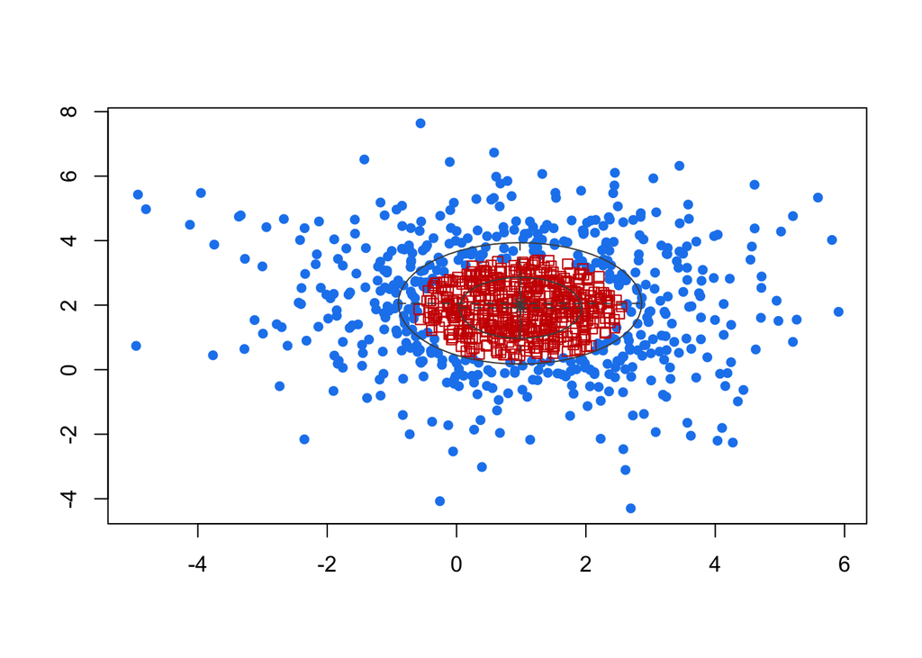

```r
plot(res,"classification")
```

### Q4 Find a partition of the simulated data into two classes using kmeans

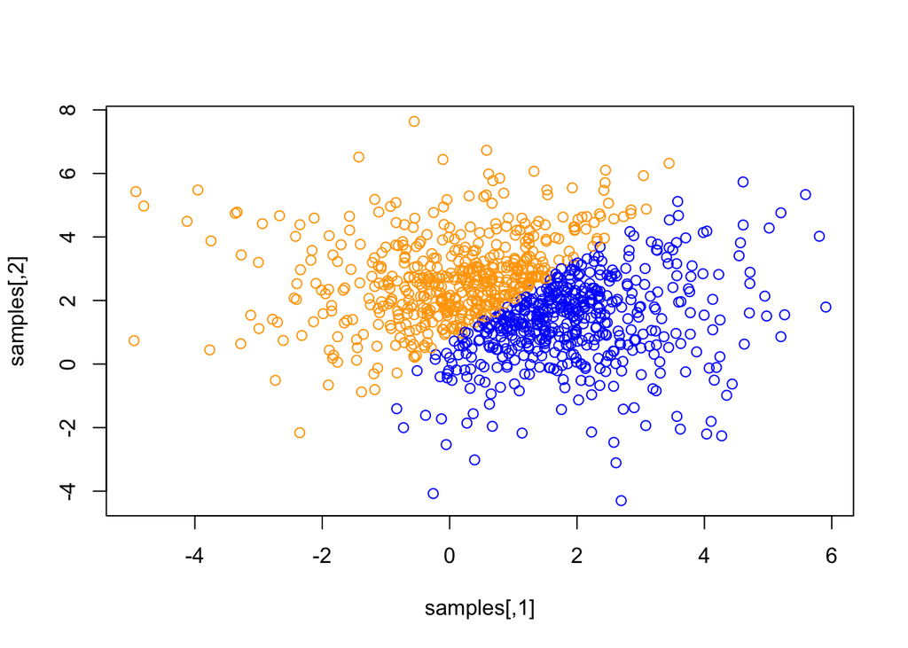

```r
kmeans(samples, 2) -> res.kmean
plot(samples, col = c("blue", "orange")[ res.kmean$cluster])
```

###Q5 Compare the two partitions (from kmeans and mclust). Comment your result. We can see that the results of kmeans and mclust are different. K-Means separate almostly the data by a straight line, but mclust separate the data by a circle. For our situation, mclust perform better.

# E3

### Q1 Detail the computation of the tqik = E[Zik] with respect to pθq(Z|X) where Zik = I(Zi=k).

$$\begin{aligned}
\mathbb{P}(x_i|Z_{ik}=1))=\mathbb{N}_p(x_i|\mu_k,\Sigma_k)&=\frac{1}{(2\pi)^{\frac{p}{2}}\times|\Sigma_k|^{\frac{1}{2}}}exp(-\frac{1}{2}(x_i-\mu_k)^T\Sigma_k^{-1}(x_i-\mu_k))
\end{aligned}$$

```r
mvpnorm<-function(x,mu,Sigma){

  p<-length(x)
   return( as.numeric(exp(-1/2*((x-mu)%*%solve(Sigma)%*%t(t(x-mu))))/det(Sigma)^(1/2)/(2*pi)^(p/2)))
}
mvpnorm(c(0,0), mu = c(0,0),Sigma = matrix(c(1,0,0,1),2,2))
```

```
## [1] 0.1591549
```

$$
$$\begin{aligned}
t_{ik}&=\mathbb{E}_{Z_{ik}|x_i}[Z_{ik}=1]\\
&=\mathbb{P}(Z_{ik}=1|x_i)\\
&=\frac{\mathbb{P}(Z_{ik}=1,x_i)}{\mathbb{P}(x_i)}\\
&=\frac{\mathbb{P}(Z_{ik}=1)\times\mathbb{P}(x_i|Z_{ik}=1)}{\sum_{l=1}^K\mathbb{P}(Z_{il}=1)\times\mathbb{P}(x_i|Z_{il}=1)}\\
&=\frac{\pi_k\times\frac{1}{2\pi^{\frac{p}{2}}\times|\Sigma_k|^{\frac{1}{2}}}exp(-\frac{1}{2}(x_i-\mu_k)^T\Sigma_k^{-1}(x_i-\mu_k))}{\sum_{l=1}^K\pi_l\times\frac{1}{2\pi^{\frac{p}{2}}\times|\Sigma_l|^{\frac{1}{2}}}exp(-\frac{1}{2}(x_i-\mu_l)^T\Sigma_l^{-1}(x_i-\mu_l))}
\end{aligned}$$

### Q2 Express Q(θq|θ) the expectation of the complete log-likelihood with respect to pθq (Z|X).

$$
$$\begin{aligned}
Q(\theta^q|\theta)&=\mathbb{E}_{Z|x}[log\mathbb{P}_\theta(x,Z)|x,\theta^q]\\
&=\mathbb{E}_{Z|x}[\sum_{i=1}^nlog \Pi_{k=1}^{K}\mathbb{P}(x_i,Z_{ik})^{Z_{ik}}]\\
&=\mathbb{E}_{Z|x}[\sum_{i=1}^n\sum_{k=1}^{K}Z_{ik}log(\pi_k\times\mathbb{P}(x_i|Z_{ik}=1))\\
&=\sum_{i=1}^n\sum_{k=1}^{K}\mathbb{E}_{Z|x}[Z_{ik}=1,\theta^q]\times log(\pi_k\mathbb{P}(x_i|Z_{ik}=1))\\
&=\sum_{i=1}^n\sum_{k=1}^{K}t_{ik}^q\times log(\pi_k\mathbb{P}(x_i|Z_{ik}=1))\\
&=\sum_{i=1}^n\sum_{k=1}^{K}t_{ik}^q\times[log(\pi_k)-\frac{1}{2}(x_i-\mu_k)^T\Sigma_k^{-1}(x_i-\mu_k)-\frac{p}{2}log(2\pi)-\frac{1}{2}log(|\Sigma_k|)]
\end{aligned}$$

### Q3 Detail the computation of θq+1 = argmaxθ Q(θq|θ)

$$\begin{aligned}
\pi^{q+1}&=argmax_{\pi^q}Q(\theta^q|\theta)\\
&=argmax_{\pi^q}\sum_{i=1}^n\sum_{k=1}^{K}t_{ik}^q\times log(\pi_k)\\
\pi_j^{q+1}&=\frac{1}{n}\sum_{i=1}^nt_{ij}^q
\\
\\
(\mu_j^{q+1},\Sigma_j^{q+1}) &=argmax_{\mu_j^q,\Sigma_j^q}Q(\theta^q|\theta)\\ &=argmax_{\mu_j^q,\Sigma_j^q}\sum_{i=1}^nt_{ij}^q\times[-\frac{1}{2}(x_i-\mu_j)^T\Sigma_j^{-1}(x_i-\mu_j)-\frac{1}{2}log(|\Sigma_j|)]\\
\mu_j^{q+1}&=\frac{ \sum_{i=1}^nt_{ij}^q \times x_i}{\sum_{i=1}^nt_{ij}^q}\\
\Sigma_j^{q+1}&=\frac{ \sum_{i=1}^nt_{ij}^q \times (x_i-\mu_j^{q+1})^T(x_i-\mu_j^{q+1}) }{\sum_{i=1}^nt_{ij}^q}
\end{aligned}$$

### Q4 Write the pseudo-code of an EM algorithm for estimating θ.

Init:Create the $\theta$ randomly; Repeat:(for iteration small than the max iteration) Compute the matrix T, compute the number Q; Compute the new $\theta$ by the matrix T; if $\Delta$Q small than $\xi$: break; For each observation of data, compute the probability of their belongs to every classes; Chose the class with the max probability;

### Q5 Write a E-step function that produces the tik from θ. Check the results by injecting the real parameters of your simulation and comparing the tik estimated against the latent variables Z in your simulation.

```r
require("mvtnorm")
Estep<-function(X,pi,mu,sigma,K){

  n<-nrow(X)
  p<-ncol(X)
  T<-matrix(0,ncol=K,nrow=n)


  for(i in 1:n){
     sum<-0
  for(l in 1:K){
    sum=sum+pi[l]*dmvnorm(X[i,], mean = mu[,l],sigma = sigma[,l*p-p+1:p])
  }

    for(k in 1:K){
      T[i,k]=pi[k]*dmvnorm(X[i,], mean = mu[,k],sigma = sigma[,k*p-p+1:p])/sum

    }

  }


  Q<-0
   for(i in 1:n){
       for(k in 1:K){
         Q=Q+T[i,k]*log(pi[k]*dmvnorm(X[i,], mean = mu[,k],sigma = sigma[,k*p-p+1:p]))
       }
   }

   result <- list(T=T, Q=Q)
  return(result)
}
```

### Q6 Write a M-step function that produces θq+1 from the sample and the tqiks.

```r
Mstep<-function(X,T,pi,mu,sigma,K){
   p<-nrow(mu)
  n<-nrow(T)
  for(j in 1:K){

  sum<-0
  for(i in 1:n){
    sum=sum+T[i,j]
  }
    pi[j]=sum/n


    sum1<-vector(length=ncol(X))
     for(i in 1:n){
    sum1=sum1+T[i,j]*X[i,]
  }
    mu[,j]=sum1/sum


   sum2<-matrix(0,p,p)
   for(i in 1:n){
    sum2=sum2+T[i,j]*(t(X[i,]-t(mu[,j]))%*%(X[i,]-t(mu[,j])))
   }
   for(i in 1: p){
     sigma[,j*p-p+i]=sum2[,i]/sum
   }
  }
   result <- list(pi=pi, mu=mu,Sigma=sigma)
  return(result)
}
```

### Q7 Program the EM algorithm (you could check that each step increases the log-likelihood.)

```r
EM<-function(data,k){
  X<-as.matrix(data)
  p<-ncol(X)
   n<-nrow(X)
  pi<-vector(length=k)
  mu<-matrix(rnorm(k*p)*10,ncol=k,nrow=p)
  Sigma<-diag(p)*abs(rnorm(1)*10)
  for(i in 1:(k-1)){
    Sigma=cbind(Sigma,diag(p)*abs(rnorm(1))*10)
  }

  for(i in 1:k){
    pi[i]=1/k
  }

  T<-matrix(0,ncol=k,nrow=n)
  Q<-2
  Q.new<-1
  max_iteration<-5
  for(i in 1:max_iteration){
    Q=Q.new
  Eres<-Estep(X,pi=pi,mu=mu,sigma=Sigma,K=k)
  T<-Eres$T
  Q.new<-Eres$Q

  #print(Q.new)

  Mres<-Mstep(X,T,pi=pi,mu=mu,sigma=Sigma,K=k)
  mu<-Mres$mu
  pi<-Mres$pi
  Sigma<-Mres$Sigma


  #print(Sigma)

  }
  res<-vector(length=n)

  for(i in 1:n){
    un<-c(0,0,0)
    for(j in 1:k){
      un[j]<- dmvnorm(X[i,], mean = mu[,j],sigma = Sigma[,j*p-p+1:p])
    }
    res[i]=which.max(un)
  }
  return(res)


}
EM(iris[,1:4],3)
```

```
##   [1] 1 1 1 1 1 1 1 1 1 1 1 1 1 1 1 1 1 1 1 1 1 1 1 1 1 1 1 1 1 1 1 1 1 1 1
##  [36] 1 1 1 1 1 1 1 1 1 1 1 1 1 1 1 1 1 1 1 1 1 1 1 1 1 1 1 1 1 1 1 1 1 1 1
##  [71] 1 1 1 1 1 1 1 1 1 1 1 1 1 1 1 1 1 1 1 1 1 1 1 1 1 1 1 1 1 1 1 1 1 1 1
## [106] 1 1 1 1 1 1 1 1 1 1 1 1 1 1 1 1 1 1 1 1 1 1 1 1 1 1 1 1 1 1 1 1 1 1 1
## [141] 1 1 1 1 1 1 1 1 1 1
```

# E4 Exercise 4 Data iris

### Q1 Run your algorithm with the iris dataset and compare the results to the one obtained using the kmeans algorithm.

```r
data("iris")
iris<-iris[,1:4]
res<-kmeans(iris,3)
res$cluster
```

```
##   [1] 3 3 3 3 3 3 3 3 3 3 3 3 3 3 3 3 3 3 3 3 3 3 3 3 3 3 3 3 3 3 3 3 3 3 3
##  [36] 3 3 3 3 3 3 3 3 3 3 3 3 3 3 3 2 2 1 2 2 2 2 2 2 2 2 2 2 2 2 2 2 2 2 2
##  [71] 2 2 2 2 2 2 2 1 2 2 2 2 2 2 2 2 2 2 2 2 2 2 2 2 2 2 2 2 2 2 1 2 1 1 1
## [106] 1 2 1 1 1 1 1 1 2 2 1 1 1 1 2 1 2 1 2 1 1 2 2 1 1 1 1 1 2 1 1 1 1 2 1
## [141] 1 1 2 1 1 1 2 1 1 2
```